# Linear Regression

```python
import os
import pandas as pd
import numpy as np
import statsmodels.api as sm
```

```python
os.getcwd()
```

```
'/Users/Jinseo_Jo/Python for Github'
```

```python
# Reading data from the csv
boston = pd.read_csv("./Boston_house.csv")
```

```python
boston.head()
```

|  | AGE | B | RM | CRIM | DIS | INDUS | LSTAT | NOX | PTRATIO | RAD | ZN | TAX | CHAS | Target |
| --- | --- | --- | --- | --- | --- | --- | --- | --- | --- | --- | --- | --- | --- | --- |
| 0 | 65.2 | 396.90 | 6.575 | 0.00632 | 4.0900 | 2.31 | 4.98 | 0.538 | 15.3 | 1 | 18.0 | 296 | 0 | 24.0 |
| 1 | 78.9 | 396.90 | 6.421 | 0.02731 | 4.9671 | 7.07 | 9.14 | 0.469 | 17.8 | 2 | 0.0 | 242 | 0 | 21.6 |
| 2 | 61.1 | 392.83 | 7.185 | 0.02729 | 4.9671 | 7.07 | 4.03 | 0.469 | 17.8 | 2 | 0.0 | 242 | 0 | 34.7 |
| 3 | 45.8 | 394.63 | 6.998 | 0.03237 | 6.0622 | 2.18 | 2.94 | 0.458 | 18.7 | 3 | 0.0 | 222 | 0 | 33.4 |
| 4 | 54.2 | 396.90 | 7.147 | 0.06905 | 6.0622 | 2.18 | 5.33 | 0.458 | 18.7 | 3 | 0.0 | 222 | 0 | 36.2 |

```python
# Number of rows, number of columns
print(boston.shape[0], boston.shape[1])
```

```
506 14
```

```python
# Remove `Target` column
boston_data = boston.drop(['Target'], axis = 1)
boston_data.describe()
```

|  | AGE | B | RM | CRIM | DIS | INDUS | LSTAT | NOX | PTRATIO | RAD | ZN | TAX | CHAS |
| --- | --- | --- | --- | --- | --- | --- | --- | --- | --- | --- | --- | --- | --- |
| count | 506.000000 | 506.000000 | 506.000000 | 506.000000 | 506.000000 | 506.000000 | 506.000000 | 506.000000 | 506.000000 | 506.000000 | 506.000000 | 506.000000 | 506.000000 |
| mean | 68.574901 | 356.674032 | 6.284634 | 3.613524 | 3.795043 | 11.136779 | 12.653063 | 0.554695 | 18.455534 | 9.549407 | 11.363636 | 408.237154 | 0.069170 |
| std | 28.148861 | 91.294864 | 0.702617 | 8.601545 | 2.105710 | 6.860353 | 7.141062 | 0.115878 | 2.164946 | 8.707259 | 23.322453 | 168.537116 | 0.253994 |
| min | 2.900000 | 0.320000 | 3.561000 | 0.006320 | 1.129600 | 0.460000 | 1.730000 | 0.385000 | 12.600000 | 1.000000 | 0.000000 | 187.000000 | 0.000000 |
| 25% | 45.025000 | 375.377500 | 5.885500 | 0.082045 | 2.100175 | 5.190000 | 6.950000 | 0.449000 | 17.400000 | 4.000000 | 0.000000 | 279.000000 | 0.000000 |
| 50% | 77.500000 | 391.440000 | 6.208500 | 0.256510 | 3.207450 | 9.690000 | 11.360000 | 0.538000 | 19.050000 | 5.000000 | 0.000000 | 330.000000 | 0.000000 |
| 75% | 94.075000 | 396.225000 | 6.623500 | 3.677082 | 5.188425 | 18.100000 | 16.955000 | 0.624000 | 20.200000 | 24.000000 | 12.500000 | 666.000000 | 0.000000 |
| max | 100.000000 | 396.900000 | 8.780000 | 88.976200 | 12.126500 | 27.740000 | 37.970000 | 0.871000 | 22.000000 | 24.000000 | 100.000000 | 711.000000 | 1.000000 |

### Dataset Characteristics

Boston house prices dataset in 1978

Number of Instances: 506

Number of Attributes: 13 numeric/categorical predictive. Median Value (attribute 14) is usually the target.

Attribute Information (in order):

- CRIM: per capita crime rate by town
- ZN: proportion of residential land zoned for lots over 25,000 sq.ft.
- INDUS: proportion of non-retail business acres per town
- CHAS: Charles River dummy variable (= 1 if tract bounds river; 0 otherwise)
- NOX: nitric oxides concentration (parts per 10 million)
- RM: average number of rooms per dwelling
- AGE: proportion of owner-occupied units built prior to 1940
- DIS: weighted distances to five Boston employment centres
- RAD: index of accessibility to radial highways
- TAX: full-value property-tax rate per \$10,000
- PTRATIO: pupil-teacher ratio by town
- B: $1000(Bk - 0.63)^2$ where Bk is the proportion of blacks by town
- LSTAT: % lower status of the population

## Linear Regression using crim/rm/lstat

```python
# Defining the variables
target = boston[['Target']]
crim = boston[['CRIM']]
rm = boston[['RM']]
lstat = boston[['LSTAT']]
```

**Note:**

```
df["colname"] - Series Type
df[["colname"]] - DataFrame Type
```

### Linear Regression Analysis: target ~ crim

```python
# Adding the constant term
crim1 = sm.add_constant(crim, has_constant = "add")
crim1
```

|  | const | CRIM |
| --- | --- | --- |
| 0 | 1.0 | 0.00632 |
| 1 | 1.0 | 0.02731 |
| 2 | 1.0 | 0.02729 |
| 3 | 1.0 | 0.03237 |
| 4 | 1.0 | 0.06905 |
| ... | ... | ... |
| 501 | 1.0 | 0.06263 |
| 502 | 1.0 | 0.04527 |
| 503 | 1.0 | 0.06076 |
| 504 | 1.0 | 0.10959 |
| 505 | 1.0 | 0.04741 |

506 rows × 2 columns

**Linear model**: \ $target = \beta_{0} + \beta_{1}crim$

**Note**: By default, statsmodels fits a line passing through the origin. In other words, it doesn't fit an intercept. Therefore, we need to use `add_constant` so that it also fits an intercept.

```python
# Performing the regression and fitting the model
model1 = sm.OLS(target, crim1)
fitted_model1 = model1.fit()
```

- Linear regression calculates an equation that minimizes the distance between the fitted line and all of the data points.
- The most common technique to estimate the parameters ($\beta$'s) of the linear model is ordinary least squares (OLS). As the name implies, OLS regression minimizes the sum of the squared residuals.
- The Formula for the Residual Sum of Squares (RSS): \begin{equation} RSS=\sum_{i=1}^n(y_{i} - f(x_{i}))^2 \end{equation} where
  - $y_{i}$ = the ith value of the variable to be predicted
  - $f(x_{i})$ = predicted value of $y_{i}$
  - n = upper limit of summation
- residual sum of squares (RSS) = sum of squared residuals (SSR) = sum of squared estimate of errors (SSE)

```python
# Summary of regression output
fitted_model1.summary()
```

OLS Regression Results

| Dep. Variable: | Target | R-squared: | 0.151 |
| --- | --- | --- | --- |
| Model: | OLS | Adj. R-squared: | 0.149 |
| Method: | Least Squares | F-statistic: | 89.49 |
| Date: | Wed, 26 May 2021 | Prob (F-statistic): | 1.17e-19 |
| Time: | 17:11:42 | Log-Likelihood: | -1798.9 |
| No. Observations: | 506 | AIC: | 3602. |
| Df Residuals: | 504 | BIC: | 3610. |
| Df Model: | 1 |  |  |
| Covariance Type: | nonrobust |  |  |

|  | coef | std err | t | P>\|t\| | [0.025 | 0.975] |
| --- | --- | --- | --- | --- | --- | --- |
| const | 24.0331 | 0.409 | 58.740 | 0.000 | 23.229 | 24.837 |
| CRIM | -0.4152 | 0.044 | -9.460 | 0.000 | -0.501 | -0.329 |

| Omnibus: | 139.832 | Durbin-Watson: | 0.713 |
| --- | --- | --- | --- |
| Prob(Omnibus): | 0.000 | Jarque-Bera (JB): | 295.404 |
| Skew: | 1.490 | Prob(JB): | 7.14e-65 |
| Kurtosis: | 5.264 | Cond. No. | 10.1 |

Notes:  
[1] Standard Errors assume that the covariance matrix of the errors is correctly specified.

**Fitted linear model:** \ $target = 24.0331 - 0.4152*crim$

**Interpreting R-squared:**

- R-squared is a statistical measure of how close the data are to the fitted regression line
- R-squared can take any values between 0 and 1
- The value shows that 15% of the data fit the regression model
- The value shows that the regression model accounts for less of the variance
- Generally, higher r-squared indicates a better fit for the model. However, it is not alwyas the case that a high r-squared is good for the regression model
- A low r-squared figure is generally a bad sign for predictive models. However, in some cases, a good model may show a small value

**Formula for calculating R-squared:**\ $$R^2 = \frac{SSR}{SST}$$ where

- SST = Total sum of squares
- SSR = Regression sum of squares
- SSE = Error sum of squares
- SST = SSE + SSR

**Interpreting the coefficients:**

- The crime coefficient in the regression equation is -0.4152
- For every 1 increase in crime, the target will dicreases with 0.4152
- If there are 20 crimes, the linear model predicts taht its target is $24.03 - (0.42 * 20) = 15.63$
- The p-value for the slope is less than 0.05. Hence, we can reject the null hypothesis which allows us to conclude that there is a relationship between crime and target
- The `CRIM` predictor variable is statistically significnat since the p-value < 0.05

```python
# Coefficients of regression output
fitted_model1.params
```

```
const    24.033106
CRIM     -0.415190
dtype: float64
```

### Compute y_hat=beta0 + beta1 * X

```python
# y_hat using dot product
pred0 = np.dot(crim1, fitted_model1.params)
pred0
```

[output not shown]

[output cut: 72 more lines]

```
        20.1597587 ,  20.90837999,  21.24397414,  21.77399775,
        21.91971708,  20.60857939,  20.08313949,  22.05996835,
        22.09465335,  20.62830508,  20.81445565,  21.20932651,
        22.03515658,  22.49976281,  21.27004809,  21.61622129,
        20.77829672,  22.71961021,  22.46577118,  22.19701851,
        17.56622696,  18.60445177,  22.22753085,  22.3563976 ,
        22.55142493,  22.10376262,  20.68842049,  21.3787449 ,
        22.0105441 ,  17.79553655,  19.78446406,  18.08189329,
        21.61503384,  21.66312533,  21.65358426,  22.8629422 ,
        23.04554703,  22.50783411,  21.66994691,  22.025383  ,
        23.97047057,  23.95697273,  23.9469708 ,  23.98920395,
        23.98688719,  23.96114955,  23.91703143,  23.95879127,
        23.91286707,  23.92167741,  23.93382587,  23.95927289,
        23.93994578,  24.00710281,  24.01431051,  24.00787921,
        23.98760547,  24.013422  ])
```

```python
# y_hat using predict() function
pred1 = fitted_model1.predict(crim1)
pred1
```

```
0      24.030482
1      24.021767
2      24.021776
3      24.019666
4      24.004437
         ...
501    24.007103
502    24.014311
503    24.007879
504    23.987605
505    24.013422
Length: 506, dtype: float64
```

```python
# Differences between pred0 and pred1
pred0 - pred1
```

```
0      0.0
1      0.0
2      0.0
3      0.0
4      0.0
      ...
501    0.0
502    0.0
503    0.0
504    0.0
505    0.0
Length: 506, dtype: float64
```

The result shows that pred0 = pred1

### Visualizing the Linear Regression

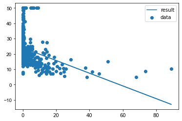

```python
import matplotlib.pyplot as plt

# Scatter plots and regression line
plt.yticks(fontname = "Arial")
plt.scatter(crim, target, label = "data")
plt.plot(crim, pred1, label = "result")
plt.legend()
plt.show()
```

The plot shows that the regression line doesn’t quite fit correctly.

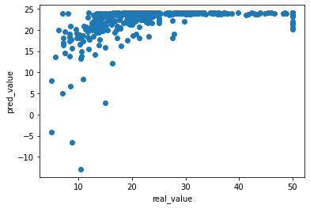

```python
# Scatter plots of actual vs. predicted values
plt.scatter(target, pred1)
plt.xlabel("real_value")
plt.ylabel("pred_value")
plt.show()
```

- Ideally, all your points should be close to a regressed diagonal line
- In ohter words, we will have predicted = actual or y = x for perfect prediction
- If the model had a high R-Squared, all the points would be close to this diagonal line. The lower the R-Squared, the weaker the Goodness of fit of the model, the more dispersed the points are (away from this diagonal line)
- In the actual vs. predicted plot, the prediction is mostly overestimating the actual outcome

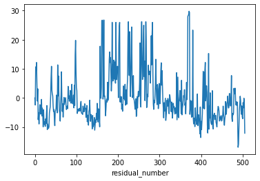

```python
# Residual plots
fitted_model1.resid.plot()
plt.xlabel("residual_number")
plt.show()
```

**Residuals:**

- Each data has one residual
  - Residual = Observed value – Predicted value
- For linear regression, the residuals always sum to zero when an intercept is included
- Since the sum of the residuals is zero, the mean of the residuals is zero
- A residual plot is a graph that shows the residuals on the vertical axis and the independent variable on the horizontal axis. If the points in a residual plot are randomly dispersed around the horizontal axis, a linear regression model is appropriate for the data; otherwise, a nonlinear model is more appropriate
- We would expect the plot to be random around the value of 0 and not show any pattern

```python
# Sum of residuals
np.sum(fitted_model1.resid)
```

```
-5.684341886080801e-13
```

We see that the sum of the residuals is almost zero.

### Linear Regression using rm and lstat

```python
rm1 = sm.add_constant(rm, has_constant = "add")
lstat1 = sm.add_constant(lstat, has_constant = "add")
```

```python
# Fit rm model
model2 = sm.OLS(target, rm1)
fitted_model2 = model2.fit()
# Fit lstat model
model3 = sm.OLS(target, lstat1)
fitted_model3 = model3.fit()
```

```python
# Summary of rm model
fitted_model2.summary()
```

OLS Regression Results

| Dep. Variable: | Target | R-squared: | 0.484 |
| --- | --- | --- | --- |
| Model: | OLS | Adj. R-squared: | 0.483 |
| Method: | Least Squares | F-statistic: | 471.8 |
| Date: | Wed, 26 May 2021 | Prob (F-statistic): | 2.49e-74 |
| Time: | 17:11:44 | Log-Likelihood: | -1673.1 |
| No. Observations: | 506 | AIC: | 3350. |
| Df Residuals: | 504 | BIC: | 3359. |
| Df Model: | 1 |  |  |
| Covariance Type: | nonrobust |  |  |

|  | coef | std err | t | P>\|t\| | [0.025 | 0.975] |
| --- | --- | --- | --- | --- | --- | --- |
| const | -34.6706 | 2.650 | -13.084 | 0.000 | -39.877 | -29.465 |
| RM | 9.1021 | 0.419 | 21.722 | 0.000 | 8.279 | 9.925 |

| Omnibus: | 102.585 | Durbin-Watson: | 0.684 |
| --- | --- | --- | --- |
| Prob(Omnibus): | 0.000 | Jarque-Bera (JB): | 612.449 |
| Skew: | 0.726 | Prob(JB): | 1.02e-133 |
| Kurtosis: | 8.190 | Cond. No. | 58.4 |

Notes:  
[1] Standard Errors assume that the covariance matrix of the errors is correctly specified.

```python
# Summary of lstat model
fitted_model3.summary()
```

OLS Regression Results

| Dep. Variable: | Target | R-squared: | 0.544 |
| --- | --- | --- | --- |
| Model: | OLS | Adj. R-squared: | 0.543 |
| Method: | Least Squares | F-statistic: | 601.6 |
| Date: | Wed, 26 May 2021 | Prob (F-statistic): | 5.08e-88 |
| Time: | 17:11:44 | Log-Likelihood: | -1641.5 |
| No. Observations: | 506 | AIC: | 3287. |
| Df Residuals: | 504 | BIC: | 3295. |
| Df Model: | 1 |  |  |
| Covariance Type: | nonrobust |  |  |

|  | coef | std err | t | P>\|t\| | [0.025 | 0.975] |
| --- | --- | --- | --- | --- | --- | --- |
| const | 34.5538 | 0.563 | 61.415 | 0.000 | 33.448 | 35.659 |
| LSTAT | -0.9500 | 0.039 | -24.528 | 0.000 | -1.026 | -0.874 |

| Omnibus: | 137.043 | Durbin-Watson: | 0.892 |
| --- | --- | --- | --- |
| Prob(Omnibus): | 0.000 | Jarque-Bera (JB): | 291.373 |
| Skew: | 1.453 | Prob(JB): | 5.36e-64 |
| Kurtosis: | 5.319 | Cond. No. | 29.7 |

Notes:  
[1] Standard Errors assume that the covariance matrix of the errors is correctly specified.

```python
pred2 = fitted_model2.predict(rm1)
pred3 = fitted_model3.predict(lstat1)
```

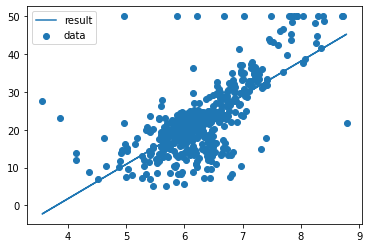

```python
# Visualizing rm model
import matplotlib.pyplot as plt
plt.scatter(rm,target,label="data")
plt.plot(rm,pred2,label="result")
plt.legend()
plt.show()
```

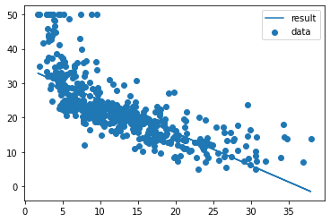

```python
# Visualizing lstat model
import matplotlib.pyplot as plt
plt.scatter(lstat,target,label="data")
plt.plot(lstat,pred3,label="result")
plt.legend()
plt.show()
```

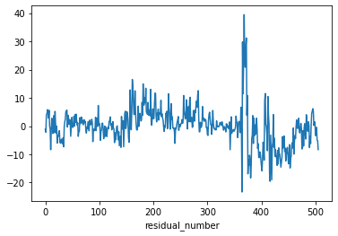

```python
# Residuals of rm model
fitted_model2.resid.plot()
plt.xlabel("residual_number")
plt.show()
```

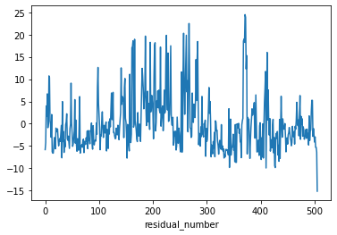

```python
# Residuals of lstat model
fitted_model3.resid.plot()
plt.xlabel("residual_number")
plt.show()
```

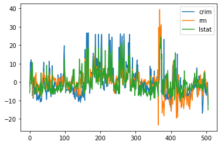

```python
# Residuals of the three models
fitted_model1.resid.plot(label = "crim")
fitted_model2.resid.plot(label = "rm")
fitted_model3.resid.plot(label = "lstat")
plt.legend()
```

The best residual plot where the residuals are close to 0: lstat model